# Part II - (Prosper Loan Data Presentation)

## by (Ndifreke Charles)

## Investigation Overview

> This Investigation, I wanted to look at the characteristics of loans that could be used to predict their borrower APR. The main focus was on the original loan amount, borrower's Prosper rating, loan term, borrower's stated monthly income

## Dataset Overview

> Prosper Loan Data (prosperloanData.csv) represents personal loans requested through Prosper's peer to peer loan servicing network. This data set contains 113,937 loans with 81 variables on each loan, including loan amount, borrower rate (or interest rate), current loan status, borrower income, and many others.

## BORROWER APR

```
Text(0.5,1,'What BorrowerAPR has the highest count?')
```

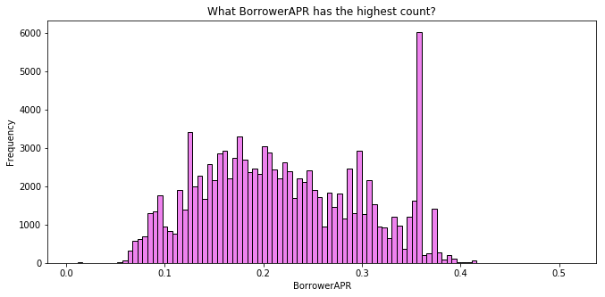

## What Loan amount is commonly requested for?

> It is observed that the commonly request loan amount is 4,000, followed by 15,000 and 10,000. Very few borrowers request for loans above 30,000.

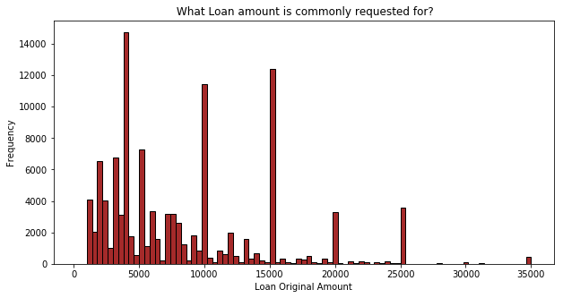

## Borrower APR by Rating and Term

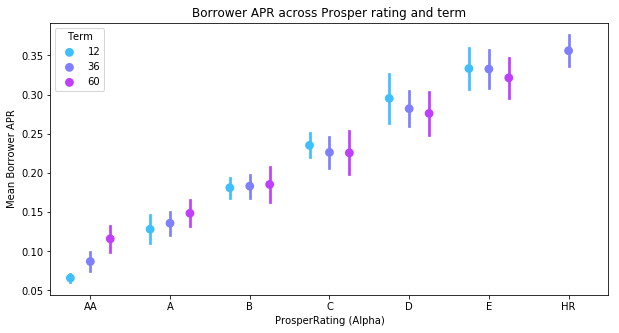

## Effect of ProsperRating (Alpha) on APR and LoanOriginalAmount

> I observed that The loan original amount increases with better rating. The borrower APR decreases with better rating.

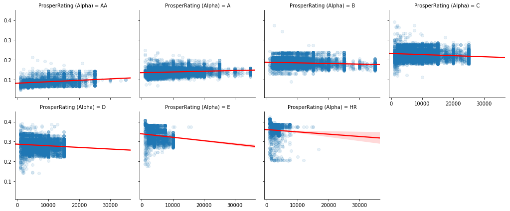